# High School Seniors t Test

```r
library(tidyverse)
library(DT)
library(pander)
library(readr)
library(car)
library(dplyr)
library(mosaic)
HSS <- read_csv("../../Data/HighSchoolSeniors.csv")
```

```r
HSS <- HSS %>%
  mutate(recycling_than_water = ifelse(Importance_recycling_rubbish >   Importance_conserving_water, "Recycling More Important", "Water Conservation More Important"))
```

I considered there might be grounds for a difference to exisit between travel times to school in different states. As I wasnt sure if this was the case I determined to us a T test to explore the difference in the mean of the travel to school from two different states. As I am comparing two different samples against one another a T Test would be appropriate. In order for a T Test’s assumptions to be satisifed I need to have two samples sizes of atleast 30 to satisify the central limit therom.

To that end I picked the two most populus states in the US, Califronia and Texas, in an effort to have the greatest likeilhood of their samples being large enough to prefrom this test. The number of responses from California was 82 and the number from Texas was 60, both well above the minimum requirements of the central limit theorm to make the data usable for a T test.

Should an individual test for normality using a QQ plot first as an intial test of normality.

## Hypthosis

Formally, the null and alternative hypotheses are written as
$$H_0: \mu_\text{Student Travel In California} - \mu_\text{Student Travel Time in Texas} = 0$$

$$H_a: \mu_\text{Student Travel In California} - \mu_\text{Student Travel Time in Texas} \neq 0$$

The significance level for this study will be set at
$$\alpha = 0.05$$

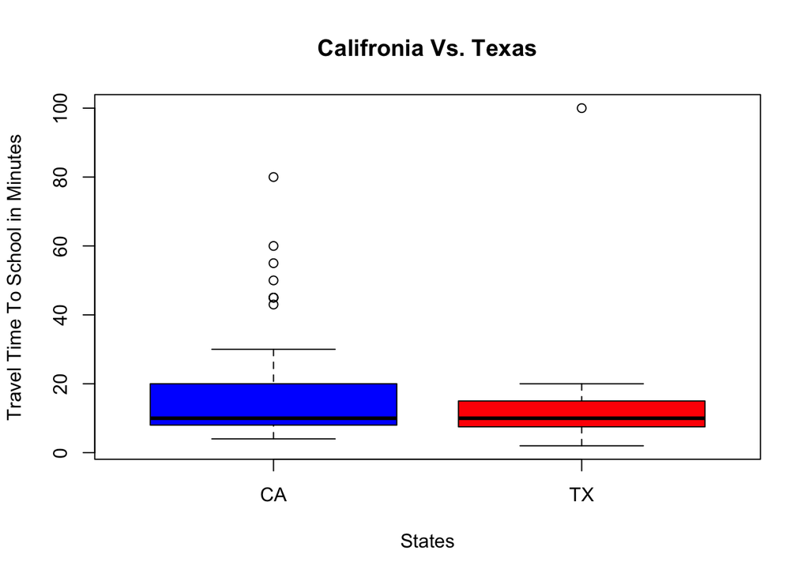

```r
HSSF<-filter(HSS, Region == "CA")
HSSG<-filter(HSS, Region == "TX")
HSST<-HSS %>% filter(Region=="CA" | Region=="TX")

boxplot(HSST$Travel_time_to_School~ HSST$Region, col=c("blue", "red"), xlab="States", ylab="Travel Time To School in Minutes", main="Califronia Vs. Texas")
```

```r
#boxplot(HSSG$Travel_time_to_School, HSSF$Travel_time_to_School, col=c("red", "blue"), xlab="States", ylab="Travel Time To School in Minutes")
```

For Reference the Blue Box Plot is data from California and the Red Box Plot is the data from Texas.